# Estudo do Modelo de Concorrência JavaFX

LP4A/PUCSP, ItaloSV, 2018

# 1 Concorrência em JavaFX

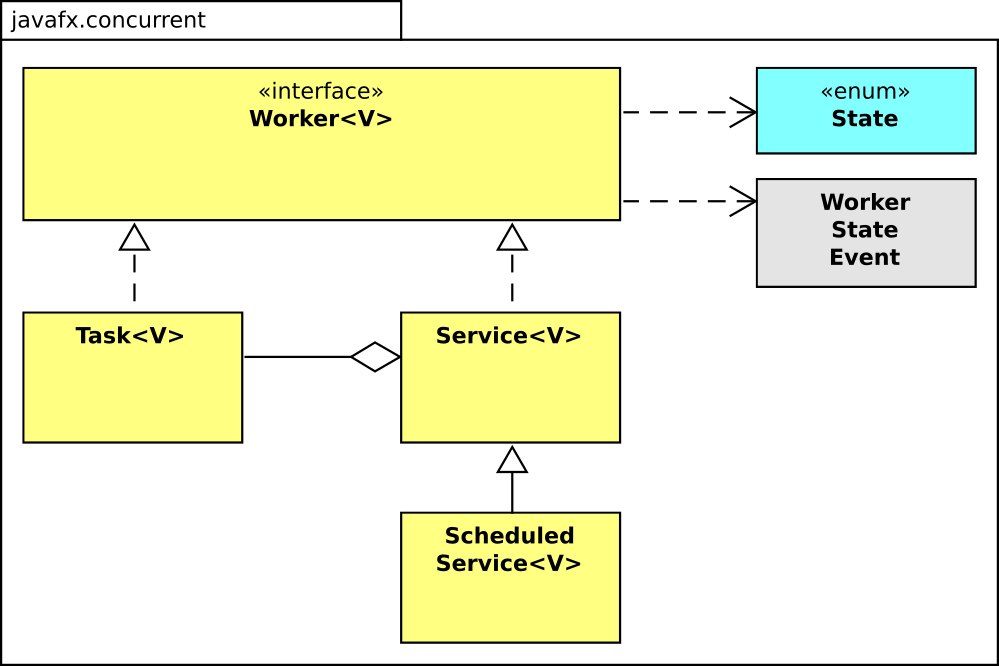

Figura 1: Modelo de concorrência JavaFX

# 2 Contagem 1

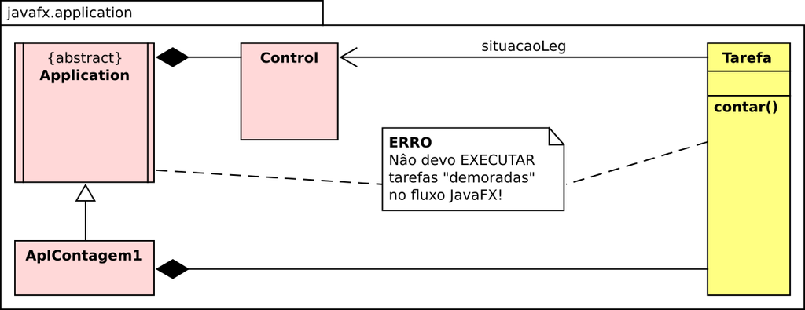

Figura 2: Efeito da execução de tarefas demoradas

## 2.1 Classe `Tarefa`

A tarefa a ser executada neste experimento (e nos demais desta série) é de geração da sequência $\langle 1,2,\cdots,10 \rangle$. As instruções que descrevem a lógica de geração serão executadas pelo fluxo JavaFX, o que deve ser evitado em situações de tarefas “demoradas”. Para simular uma tarefa deste tipo, acrescentaremos uma instrução que suspende a execução do objeto ativo contendo o fluxo de controle JavaFX (lst. 1).

Listagem 1: Lógica de geração da sequência de números

```java
    // Tarefa (0.1)::
    void contar() {
        // Lógica da tarefa a ser realizada
        String s = "--- Fluxo= " + Thread.currentThread().getName();
        System.out.println(s); // <--(1)
        for (int i = 1; i <= 10; i++) {
            String situacao = "Contando " + i + " de " + 10;
            situacaoLeg.setText(situacao); // <--(2)
            System.out.println(situacao);
            try {
                Thread.sleep(1000);
            } catch (InterruptedException e) {
                System.out.println("*** ERRO: " + e);
            }
        }
    }
```

A instrução (1) faz o objeto ativo identificar-se no terminal de execução Java. A instrução (2), foco primário deste experimento, força o objeto ativo a atualizar um elemento visual de interação com o usuário. Como, em seguida, iremos suspender este objeto por 1s, o usuário será impedido de interagir com a interface da aplicação.

Devido à instrução (2), precisaremos da interface `Label` (lst. 2).

Listagem 2: Interface exigida pela classe Tarefa

```java
// Tarefa (0.1)::
import javafx.scene.control.Label;
```

e, também, associar a tarefa com este elemento visual em tempo de execução—e antes do início da realização da tarefa—conforme se executa o método `associar()` (lst. 3).

Listagem 3: Método para associar a tarefa ao fluxo JavaFX

```java
    // Tarefa (0.1)::
    void associar(Label s) {
        situacaoLeg = s;
    }
    Label situacaoLeg;
```

## 2.2 Classe `AplContagem1`

A interface exigida pela aplicação deste cenário revela as operações necessárias para a implementação deste cenário (lst. 4).

Listagem 4: Interface exigida pela classe AplContagem1

```java
// AplContagem1 (0.1)::
import javafx.application.Application;
import javafx.scene.Scene;
import javafx.scene.control.Button;
import javafx.scene.control.Label;
import javafx.scene.layout.HBox;
import javafx.scene.layout.VBox;
import javafx.stage.Stage;
```

**Criação do fluxo JavaFX** A criação do fluxo de controle JavaFX é típico nas aplicações que se utilizam desta tecnologia (lst. 5).

Listagem 5: Método do fluxo de controle principal

```java
    // AplContagem1 (0.1)::
    public static void main(String[] args) {
        Application.launch(args);
    }
```

**Construção da interface de controle** O método `start()` contém a sequência de instruções inicialmente executadas pelo objeto ativo da classe `AplContagem1`. Vale lembrar que o fluxo de controle de execução deste objeto é aquele fluxo JavaFX, criado pelo fluxo `main` (lst. 6).

Listagem 6: Método da ação inicial realizada pelo fluxo JavaFX

```java
    // AplContagem1 (0.1)::
    @Override
    public void start(Stage palco) {
        // Tarefa de contagem
        Tarefa c = new Tarefa();
        // Elementos visuais
        Button contarEvt = definirBotaoContar(c);
        Button encerrarEvt = definirBotaoEncerrar(c, palco);
        Label situacaoLeg = definirTextoSituacao(c);
        // Organzação dos elementos visuais
        HBox botaoSeq = new HBox(50, contarEvt, encerrarEvt);
        VBox raiz = new VBox(10, situacaoLeg, botaoSeq);
        // Cena principal
        Scene cena = new Scene(raiz);
        palco.setScene(cena);
        palco.setTitle("Contagem 1");
        palco.show();
    }
```

**Mecanismos de geração de eventos** O código para a construção dos elementos de controle da inteface com o usuário é mostrado nas lst. 7, lst. 8 e lst. 9.

Listagem 7: Construção do botão de contagem

```java
    // AplContagem1 (0.1)::
    Button definirBotaoContar(Tarefa c) {
        // Eventos do usuário
        Button botao = new Button("Contar");
        botao.setOnAction(e -> c.contar());
        return botao;
    }
```

Listagem 8: Construção do botão de encerramento

```java
    // AplContagem1 (0.1)::
    Button definirBotaoEncerrar(Tarefa c, Stage palco) {
        // Eventos do usuário
        Button botao = new Button("Encerrar");
        botao.setOnAction(e -> palco.close());
        return botao;
    }
```

Listagem 9: Construção do controle de informação de contagem

```java
    // AplContagem1 (0.1)::
    Label definirTextoSituacao(Tarefa c) {
        Label rotulo = new Label("Não começou...");
        c.associar(rotulo);
        return rotulo;
    }
```

## 2.3 Considerações

Pela execução do programa `AplContagem1` observaremos que, ao ser iniciada a realização da tarefa de contagem, a aplicação perderá a capacidade de interagir. Somente após o término da geração da sequência de números é que a aplicação recuperará a sua capacidade interativa.

Agora, o que acontece se, durante a realização da contagem, gerarmos eventos do tipo **Encerrar**? Porquê?

# 3 Contagem 2

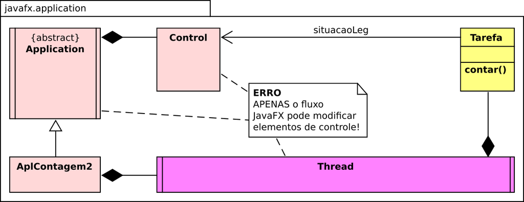

Figura 3: Compartilhamento de controles

## 3.1 Classe `Tarefa`

Esta classe permanece como no cenário do experimento anterior.

Listagem 10: Interface exigida da tarefa

```java
    // Tarefa (0.2)::
import javafx.scene.control.Label;
```

Listagem 11: Caminho para as instruções da área de controle

```java
    // Tarefa (0.2)::
    void associar(Label s) {
        situacaoLeg = s;
    }
    Label situacaoLeg;
```

Listagem 12: Lógica de geração da sequência de números

```java
    // Tarefa (0.2)::
    void contar() {
        // Lógica da tarefa a ser realizada
        String s = "--- Fluxo= " + Thread.currentThread().getName();
        System.out.println(s); // <--(1)
        for (int i = 1; i <= 10; i++) {
            String situacao = "Contando " + i + " de " + 10;
            situacaoLeg.setText(situacao); // <--(2)
            System.out.println(situacao);
            try {
                Thread.sleep(1000);
            } catch (InterruptedException e) {
                System.out.println("*** ERRO: " + e);
            }
        }
    }
```

## 3.2 Classe `AplContagem2`

**Interface exigida, fluxos principal e JavaFX** Esta parte do experimento repete o anterior.

Listagem 13: Interface exigida

```java
// AplContagem2 (0.2)::
import javafx.application.Application;
import javafx.scene.Scene;
import javafx.scene.control.Button;
import javafx.scene.control.Label;
import javafx.scene.layout.HBox;
import javafx.scene.layout.VBox;
import javafx.stage.Stage;
```

Listagem 14: Criação do fluxo JavaFX

```java
    // AplContagem2 (0.2)::
    public static void main(String[] args) {
        Application.launch(args);
    }
```

Listagem 15: Ação inicial do fluxo JavaFX

```java
    // AplContagem2 (0.2)::
    @Override
    public void start(Stage palco) {
        // Tarefa de contagem
        Tarefa c = new Tarefa();
        // Elementos visuais
        Button contarEvt = definirBotaoContar(c);
        Button encerrarEvt = definirBotaoEncerrar(c, palco);
        Label situacaoLeg = definirTextoSituacao(c);
        // Organzação dos elementos visuais
        HBox botaoSeq = new HBox(50, contarEvt, encerrarEvt);
        VBox raiz = new VBox(10, situacaoLeg, botaoSeq);
        // Cena principal
        Scene cena = new Scene(raiz);
        palco.setScene(cena);
        palco.setTitle("Contagem 2");
        palco.show();
    }
```

**Eventos de contagem** A principal modificação ocorre na definição do botão para gerar eventos **Contar**. Vincularemos o botão ao método `contar()` (lst. 16).

Listagem 16: Construção do botão que gera eventos de contagem

```java
    // AplContagem2 (0.2)::
    Button definirBotaoContar(Tarefa c) {
        // Eventos do usuário
        Button botao = new Button("Contar");
        botao.setOnAction(e -> contar(c));
        return botao;
    }
```

A execução deste método irá criar um novo fluxo de controle, responsável por executar as instruções da tarefa de contagem (lst. 17)

Listagem 17: Criação de um novo fluxo de controle, específico para contagem

```java
    // AplContagem2 (0.2)::
    void contar(Tarefa c) {
        Runnable tarefa = () -> c.contar();
        Thread fluxoAdicional = new Thread(tarefa);
        // Encerro o fluxo de controle se a aplicação terminar
        fluxoAdicional.setDaemon(true);
        fluxoAdicional.start();
    }
```

É durante a realização da tarefa que deveremos observar um comportamento anômalo. Na tecnologia JavaFX, apenas o fluxo JavaFX pode executar instruções que se encontram nas classes de controle. Em particular, existe uma região neste experimento que deveria ser percorrida apenas por este fluxo: a região delimitada pelo objeto `situacaoLeg` da classe `Label`. Entretanto, programamos o fluxo de controle de contagem para também percorrer por aquela região de instruções. Isto será proibido pelo ambiente de execução JavaFX. Consequentemente, observaremos um erro em tempo de execução. No próximo experimento iremos resolver esta questão.

**Demais elementos de controle** Tanto o botão para encerrar quanto o elemento visual que informa sobre o processo de contagem não se alteram.

Listagem 18: Construção do botão de encerramento

```java
    // AplContagem2 (0.2)::
    Button definirBotaoEncerrar(Tarefa c, Stage palco) {
        // Eventos do usuário
        Button botao = new Button("Encerrar");
        botao.setOnAction(e -> palco.close());
        return botao;
    }
```

Listagem 19: Construção do controle de informação de contagem

```java
    // AplContagem2 (0.2)::
    Label definirTextoSituacao(Tarefa c) {
        Label rotulo = new Label("Não começou...");
        c.associar(rotulo);
        return rotulo;
    }
```

## 3.3 Considerações

Pela execução do programa `AplContagem2` observaremos que, ao ser iniciada a realização da tarefa de contagem, a aplicação será interrompida. Explique o funcionamento após clicar no botão **Contar**. Qual **instrução** do programa provocou a falha de execução?

# 4 Contagem 3

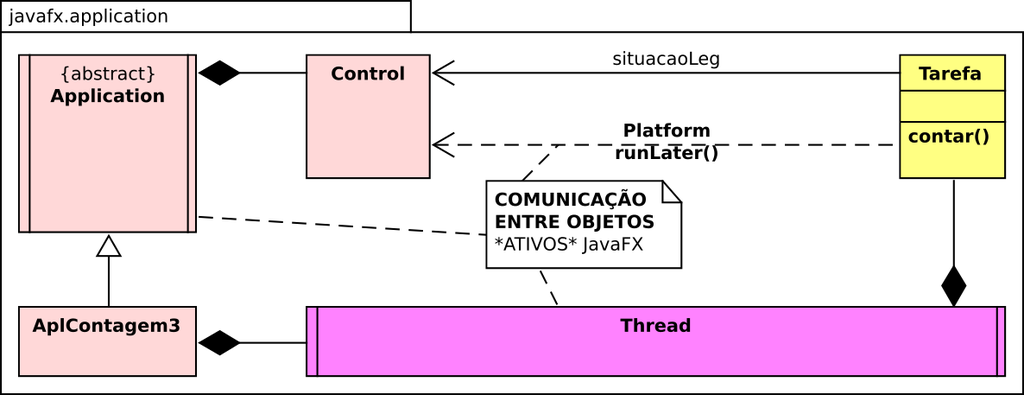

Figura 4: Conector de comunicação entre objetos ativos

## 4.1 Classe `Tarefa`

O método `contar()` sofre a principal alteração neste experimento. A comunicação entre o fluxo de contagem e o fluxo JavaFX será feita pelo conector `Platform`, como destacado na instrução (1) da lst. 20.

Listagem 20: Lógica de geração da sequência de números

```java
    // Tarefa (0.3)::
    void contar() {
        // Lógica da tarefa a ser realizada
        String s = "--- Fluxo= " + Thread.currentThread().getName();
        System.out.println(s);
        for (int i = 1; i <= 10; i++) {
            String situacao = "Contando " + i + " de " + 10;
            Platform.runLater(() -> situacaoLeg.setText(situacao)); // <--(1)
            System.out.println(situacao);
            try {
                Thread.sleep(1000);
            } catch (InterruptedException e) {
                System.out.println("*** ERRO: " + e);
            }
        }
    }
```

O restante da definição desta classe permanece inalterada em relação ao experimento anterior, lst. 21 e lst. 22.

Listagem 21: Interface exigida da tarefa

```java
// Tarefa (0.3)::
import javafx.application.Platform; // <--(1)
import javafx.scene.control.Label;
```

Listagem 22: Caminho para as instruções da área de controle

```java
    // Tarefa (0.3)::
    void associar(Label s) {
        situacaoLeg = s;
    }
    Label situacaoLeg;
```

## 4.2 Classe `AplContagem3`

**Interface exigida, fluxos principal e JavaFX** Esta parte do experimento repete o anterior.

Listagem 23: Interface exigida

```java
// AplContagem3 (0.3)::
import javafx.application.Application;
import javafx.scene.Scene;
import javafx.scene.control.Button;
import javafx.scene.control.Label;
import javafx.scene.layout.HBox;
import javafx.scene.layout.VBox;
import javafx.stage.Stage;
```

Listagem 24: Criação do fluxo JavaFX

```java
    // AplContagem3 (0.3)::
    public static void main(String[] args) {
        Application.launch(args);
    }
```

Listagem 25: Ação inicial do fluxo JavaFX

```java
    // AplContagem3 (0.3)::
    @Override
    public void start(Stage palco) {
        // Tarefa de contagem
        Tarefa c = new Tarefa();
        // Eventos do usuário
        Button contarEvt = definirBotaoContar(c);
        Button encerrarEvt = definirBotaoEncerrar(c, palco);
        Label situacaoLeg = definirTextoSituacao(c);
        // Organzação dos elementos visuais
        HBox botaoSeq = new HBox(50, contarEvt, encerrarEvt);
        VBox raiz = new VBox(10, situacaoLeg, botaoSeq);
        // Cena principal
        Scene cena = new Scene(raiz);
        palco.setScene(cena);
        palco.setTitle("Contagem 3");
        palco.show();
    }
```

**Eventos de contagem** Os elementos que se referem diremente à tarefa de contagem também não se alteram em relação ao experimento anterior.

Listagem 26: Construção do botão que gera eventos de contagem

```java
    // AplContagem3 (0.1)::
    Button definirBotaoContar(Tarefa c) {
        // Eventos do usuário
        Button botao = new Button("Contar");
        botao.setOnAction(e -> contar(c));
        return botao;
    }
```

Listagem 27: Criação de um novo fluxo de controle, específico para contagem

```java
    // AplContagem3 (0.3)::
    void contar(Tarefa c) {
        Runnable tarefa = () -> c.contar();
        Thread fluxoAdicional = new Thread(tarefa);
        // Encerro o fluxo de controle se a aplicação terminar
        fluxoAdicional.setDaemon(true);
        fluxoAdicional.start();
    }
```

Listagem 28: Construção do botão de encerramento

```java
    // AplContagem3 (0.3)::
    Button definirBotaoEncerrar(Tarefa c, Stage palco) {
        // Eventos do usuário
        Button botao = new Button("Encerrar");
        botao.setOnAction(e -> palco.close());
        return botao;
    }
```

Listagem 29: Construção do controle de informação de contagem

```java
    // AplContagem3 (0.3)::
    Label definirTextoSituacao(Tarefa c) {
        Label rotulo = new Label("Não começou...");
        c.associar(rotulo);
        return rotulo;
    }
```

## 4.3 Considerações

Durante a execução do programa `AplContagem3`, explique o funcionamento após clicar no botão **Contar** várias vezes. Em um DCL, destaque as classes contendo as instruções executadas pelos dois fluxos de controle.

# 5 Contagem 4

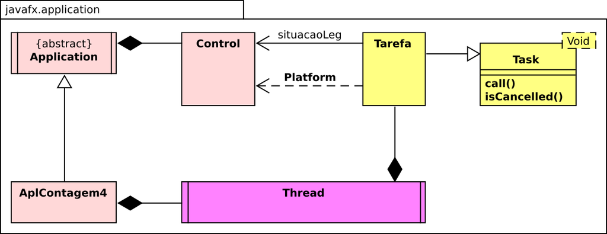

Figura 5: Fluxos sobre tarefas não reusáveis

## 5.1 Classe `Tarefa`

1. `Tarefa` como uma extensão de `Task` e
2. definição do método `call()`, executado no momento em que o fluxo de controle de contagem inicia a sua corrida.

**Definição da classe `Tarefa`**

```java
public class Tarefa extends Task<Void> {
```

**Definição do método `call()`** Este método será executado quando enviarmos uma mensagem `start()` para o fluxo de contagem (lst. 30).

Listagem 30: Método chamado na corrida inicial do fluxo de contagem

```java
    // Tarefa (0.4)::
    @Override
    protected Void call() throws Exception {
        contar();
        return null;
    }
```

**Restante da classe `Tarefa`** O restante da definição desta classe permanece inalterada em relação ao experimento anterior, lst. 31, lst. 32 e lst. 33.

Listagem 31: Interface exigida da tarefa

```java
// Tarefa (0.4)::
import javafx.application.Platform;
import javafx.concurrent.Task; // <--(1)
import javafx.scene.control.Label;
```

Listagem 32: Caminho para as instruções da área de controle

```java
    // Tarefa (0.4)::
    void associar(Label s) {
        situacaoLeg = s;
    }
    Label situacaoLeg;
```

Listagem 33: Lógica de geração da sequência de números

```java
    // Tarefa (0.4)::
    void contar() {
        // Lógica da tarefa a ser realizada
        String s = "--- Fluxo= " + Thread.currentThread().getName();
        System.out.println(s);
        for (int i = 1; i <= 10; i++) {
            String situacao = "Contando " + i + " de " + 10;
            // Atualizo o Label no fluxo JavaFx
            Platform.runLater(() -> situacaoLeg.setText(situacao));
            System.out.println(situacao);
            try {
                Thread.sleep(1000);
            } catch (InterruptedException e) {
                System.out.println("*** ERRO: " + e);
            }
        }
    }
```

## 5.2 Classe `AplContagem4`

**Interface exigida, fluxos principal e JavaFX** Esta parte do experimento repete o anterior.

Listagem 34: Interface exigida

```java
// AplContagem4 (0.4)::
import javafx.application.Application;
import javafx.scene.Scene;
import javafx.scene.control.Button;
import javafx.scene.control.Label;
import javafx.scene.layout.HBox;
import javafx.scene.layout.VBox;
import javafx.stage.Stage;
```

Listagem 35: Criação do fluxo JavaFX

```java
    // AplContagem4 (0.4)::
    public static void main(String[] args) {
        Application.launch(args);
    }
```

Listagem 36: Ação inicial do fluxo JavaFX

```java
    // AplContagem4 (0.4)::
    @Override
    public void start(Stage palco) {
        // Tarefa de contagem
        Tarefa c = new Tarefa();
        // Eventos do usuário
        Button contarEvt = definirBotaoContar(c);
        Button encerrarEvt = definirBotaoEncerrar(c, palco);
        Label situacaoLeg = definirTextoSituacao(c);
        // Organzação dos elementos visuais
        HBox botaoSeq = new HBox(50, contarEvt, encerrarEvt);
        VBox raiz = new VBox(10, situacaoLeg, botaoSeq);
        // Cena principal
        Scene cena = new Scene(raiz);
        palco.setScene(cena);
        palco.setTitle("Contagem 4");
        palco.show();
    }
```

**Eventos de contagem** Os elementos que se referem diremente à tarefa de contagem também não se alteram em relação ao experimento anterior.

Listagem 37: Construção do botão que gera eventos de contagem

```java
    // AplContagem4 (0.4)::
    Button definirBotaoContar(Tarefa c) {
        // Eventos do usuário
        Button botao = new Button("Contar");
        botao.setOnAction(e -> contar(c));
        return botao;
    }
```

Listagem 38: Criação de um novo fluxo de controle, específico para contagem

```java
    // AplContagem4 (0.4)::
    void contar(Tarefa c) {
        Thread fluxoAdicional = new Thread(c);
        // Encerro o fluxo de controle se a aplicação terminar
        fluxoAdicional.setDaemon(true);
        fluxoAdicional.start();
    }
```

Listagem 39: Construção do botão de encerramento

```java
    // AplContagem4 (0.4)::
    Button definirBotaoEncerrar(Tarefa c, Stage palco) {
        // Eventos do usuário
        Button botao = new Button("Encerrar");
        botao.setOnAction(e -> palco.close());
        return botao;
    }
```

Listagem 40: Construção do controle de informação de contagem

```java
    // AplContagem4 (0.4)::
    Label definirTextoSituacao(Tarefa c) {
        Label rotulo = new Label("Não começou...");
        c.associar(rotulo);
        return rotulo;
    }
```

## 5.3 Considerações

Durante a execução do programa `AplContagem4`, explique o funcionamento após clicar no botão **Contar** várias vezes. Em um DCL, destaque as classes contendo as instruções executadas pelos dois fluxos de controle.

# 6 Contagem 5

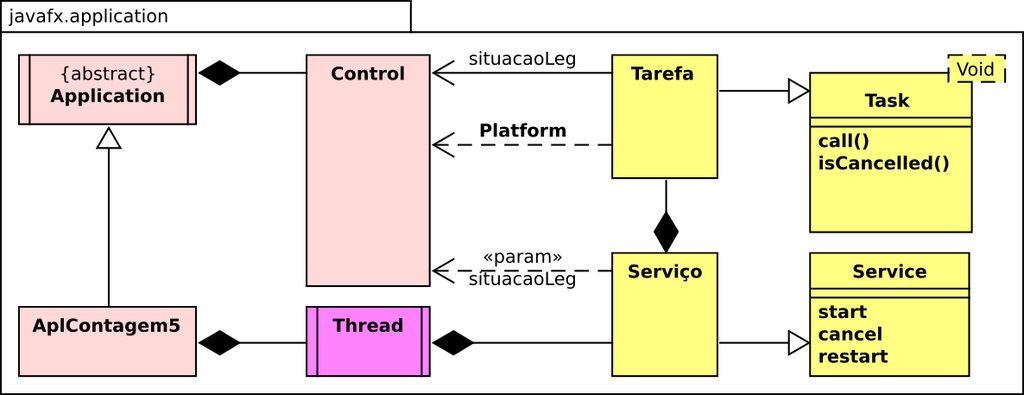

Figura 6: Serviços e tarefas reusáveis

## 6.1 Classe `Tarefa`

Faremos uma única alteração nesta classe (lst. 41): no método `contar()` adicionamos uma decisão de parada do processo de contagem.

Listagem 41: Lógica de geração da sequência de números

```java
    // Tarefa (0.5)::
    void contar() {
        // Lógica da tarefa a ser realizada
        String s = "--- Fluxo= " + Thread.currentThread().getName();
        System.out.println(s);
        for (int i = 1; i <= 10; i++) {
            if (this.isCancelled()) { // <--(1)
                break;
            }
            String situacao = "Contando " + i + " de " + 10;
            // Atualizo o Label no fluxo JavaFx
            Platform.runLater(() -> situacaoLeg.setText(situacao));
            System.out.println(situacao);
            try {
                Thread.sleep(1000);
            } catch (InterruptedException e) {
                System.out.println("--- AVISO: " + e);
            }
        }
    }
```

Segundo o manual da tecnologia JavaFX:

> In Java there is no reliable way to “kill” a thread in process. However, when **cancel** is called on a `Task`, it is important that the `Task` stop processing. A “run-away” `Task` might continue processing and updating the message, text, and progress properties even after the `Task` has been cancelled! In Java, cancelling a `Task` is a **cooperative endeavor**. The user of the `Task` will request that it be cancelled, and the **author** of the `Task` **must check** whether is has been cancelled within the body of the call method. There are two ways this can be done. First, the `Task` author may check the **isCancelled** method, inherited from `FutureTask`, to see whether the `Task` has been cancelled… https://docs.oracle.com/javase/8/javafx/api/javafx/concurrent/Task.html

**Restante da classe `Tarefa`** O restante da definição desta classe permanece inalterada em relação ao experimento anterior, lst. 42, lst. 43 e lst. 44.

Listagem 42: Interface exigida da tarefa

```java
// Tarefa (0.5)::
import javafx.application.Platform;
import javafx.concurrent.Task; // <--(1)
import javafx.scene.control.Label;
```

Listagem 43: Caminho para as instruções da área de controle

```java
    // Tarefa (0.5)::
    void associar(Label s) {
        situacaoLeg = s;
    }
    Label situacaoLeg;
```

Listagem 44: Método chamado na corrida inicial do fluxo de contagem

```java
    // Tarefa (0.5)::
    @Override
    protected Void call() throws Exception {
        contar();
        return null;
    }
```

## 6.2 Classe `Servico`

Esta nova classe corresponde a uma região do programa percorrida pelo fluxo de contagem apenas. Ela contém informações que irão permitir que o fluxo seja reiniciado (lst. 45).

Listagem 45: Classe que coordenará a realização da tarefa

```java
// Tarefa (0.5)::
import javafx.concurrent.Service;
import javafx.concurrent.Task;
import javafx.scene.control.Label;

public class Servico extends Service<Void> {

    void associar(Label s) {
        situacaoLeg = s;
    }
    Label situacaoLeg;

    @Override
    protected Task<Void> createTask() {
        // Chamado quando o serviço começa ou reiniciado
        Tarefa c = new Tarefa();
        c.associar(situacaoLeg);
        return c;
    }
}
```

## 6.3 Classe `AplContagem5`

**Fluxo adicional** O ponto central deste experimento encontra-se no método `start()` (lst. 46). Mais especificamente, na instrução destacada (1). Na tecnologia JavaFX, quando instanciamos um objeto `Service`, o ambiente de execução cria um novo fluxo de controle que irá correr pelas suas instruções. Desta maneira, interpretamos o objeto identificado por `fluxoAdicional` de duas maneiras. Por um lado, ele corresponde ao fluxo criado automaticamente pelo ambiente JavaFX. Por outro lado, ele contém a região de instruções que serão, por ele, executadas (métodos da classe `Servico`, neste caso).

Listagem 46: Ação inicial do fluxo JavaFX

```java
    // AplContagem5 (0.5)::
    @Override
    public void start(Stage palco) {
        // Tarefa de contagem
        Servico fluxoAdicional = new Servico(); // <--(1)
        // Eventos do usuário
        Button contarEvt = definirBotaoContar(fluxoAdicional);
        Button pausarEvt = definirBotaoPausar(fluxoAdicional);
        Button continuarEvt = definirBotaoContinuar(fluxoAdicional);
        Button encerrarEvt = definirBotaoEncerrar(palco);
        Label situacaoLeg = definirTextoSituacao(fluxoAdicional);
        // Organzação dos elementos visuais
        HBox botaoSeq = new HBox(5, contarEvt, pausarEvt, continuarEvt, encerrarEvt);
        VBox raiz = new VBox(10, situacaoLeg, botaoSeq);
        // Cena principal
        Scene cena = new Scene(raiz);
        palco.setScene(cena);
        palco.setTitle("Contagem 5");
        palco.show();
    }
```

Além disso, quando dermos início à corrida deste fluxo, ele passará pela instanciação da tarefa de contagem em si (classe `Tarefa`), cujas instruções determinam como deverão ser gerados os números da sequência $\langle 1,2,\cdots,10 \rangle$.

**Interface exigida, fluxos principal e JavaFX** Esta parte do experimento repete o anterior.

Listagem 47: Interface exigida

```java
// AplContagem5 (0.5)::
import javafx.application.Application;
import javafx.scene.Scene;
import javafx.scene.control.Button;
import javafx.scene.control.Label;
import javafx.scene.layout.HBox;
import javafx.scene.layout.VBox;
import javafx.stage.Stage;
```

Listagem 48: Criação do fluxo JavaFX

```java
    // AplContagem5 (0.5)::
    public static void main(String[] args) {
        Application.launch(args);
    }
```

**Construção dos botões de eventos** Neste experimento, iremos adicionar dois novos botões: um para pausar a contagem e outro para continuá-la (lst. 46). A construção destes botões segue o padrão daquele utilizado no caso do botão que inicia a contagem.

Listagem 49: Construção do botão que gera eventos de contagem

```java
    // AplContagem5 (0.5)::
    Button definirBotaoContar(Servico fluxoAdicional) {
        // Eventos do usuário
        Button botao = new Button("Contar");
        botao.setOnAction(e -> contar(fluxoAdicional));
        return botao;
    }
```

Listagem 50: Construção do botão que gera eventos de pausa da contagem

```java
    // AplContagem5 (0.5)::
    Button definirBotaoPausar(Servico fluxoAdicional) {
        // Eventos do usuário
        Button botao = new Button("Pausar");
        botao.setOnAction(e -> pausar(fluxoAdicional));
        return botao;
    }
```

Listagem 51: Construção do botão que gera eventos de continuação da contagem

```java
    // AplContagem5 (0.5)::
    Button definirBotaoContinuar(Servico fluxoAdicional) {
        // Eventos do usuário
        Button botao = new Button("Continuar");
        botao.setOnAction(e -> continuar(fluxoAdicional));
        return botao;
    }
```

Associados a cada um destes botões, encontramos os métodos que definem a reação aos respectivos tipos de eventos (lst. 52).

Listagem 52: Criação de um novo fluxo de controle, específico para contagem

```java
    // AplContagem5 (0.5)::
    void contar(Servico fluxoAdicional) {
        fluxoAdicional.start();
    }

    void pausar(Servico fluxoAdicional) {
        fluxoAdicional.cancel();
    }

    void continuar(Servico fluxoAdicional) {
        fluxoAdicional.restart();
    }
```

**Informações sobre a contagem** Não alteramos este elemento informativo.

Listagem 53: Construção do controle de informação de contagem

```java
    // AplContagem5 (0.5)::
    Label definirTextoSituacao(Servico fluxoAdicional) {
        Label rotulo = new Label("Não começou...");
        fluxoAdicional.associar(rotulo);
        return rotulo;
    }
```

## 6.4 Considerações

Durante a execução do programa `AplContagem5`, explique o funcionamento após clicar no botão

- **Contar**,
- **Pausar** e
- **Continuar**.